# Regressão linear

### **Autor**: Osvaldo César Cuba Margato

#### Linguagem utilizada: Python 3.6

## Introdução

Regressão linear é o processo de, a partir de pontos dispersos em um gráfico, traçar uma reta para poder fazer previsões a partir desses dados.

[figure not shown]

## Encontrar a equação

Para encontrar uma equação com o menor erro possível que se relaciona com a dispersão dada no gráfico, utilizamos o *método dos mínimos quadrados*.

Sabendo-se que a equação é do tipo: \begin{equation} y=a+bx \end{equation}

Pelo método, temos o seguinte sistema para ajustar a reta:  
\begin{equation} \begin{cases} (\sum_{i=1}^{n}x_{i}^2)a+(\sum_{i=1}^{n}x_{i})b=\sum_{i=1}^{n}x_if(x_i)\\ (\sum_{i=1}^{n}x_{i})a+nb=\sum_{i=1}^{n}f(x_i) \end{cases} \\ \text{Sendo } n = \text{Número de pontos} \end{equation}

Logo:

\begin{equation} b = \dfrac{n(\sum_{i=1}^{n}x_if(x_i))-(\sum_{i=1}^{n}x_i))(\sum_{i=1}^{n}f(x_i))}{n(\sum_{i=1}^{n}x_{i}^2)-\sum_{i=1}^{n}x_{i}^2} \end{equation}

\begin{equation} a = \dfrac{(\sum_{i=1}^{n}x_i^2)(\sum_{i=1}^{n}f(x_i))-(\sum_{i=1}^{n}x_if(x_i))(\sum_{i=1}^{n}x_i)}{n(\sum_{i=1}^{n}x_{i}^2)-\sum_{i=1}^{n}(x_{i})^2} \end{equation}

Com isso, descobrimos os parâmetros da reta e podemos traçá-la no gráfico.

# Programa

No código abaixo, o método dos mínimos quadrados é implementado para traçar uma reta numa relação entre as décadas de 80 à 90 e a população da época em bilhão.

### Importação dos módulos necessários e conversão dos dados salvos no arquivo para um array

```python
%matplotlib inline
import matplotlib.pyplot as plt
import matplotlib.ticker as mticker
import sys
import math
import numpy as np

# Initialize program
file = open('data.txt')
line = file.readline()
data = []

# Add file content to data var
while line:
    year, population = line.split(',')
    data.append((int(year), float(population)))
    line = file.readline()

for year, population in data:
    print(year, population)
```

```
1980 4.454
1981 4.53
1982 4.61
1983 4.69
1984 4.77
1985 4.851
1986 4.933
1987 5.018
1988 5.105
1989 5.19
1990 5.277
1991 5.359
1992 5.442
1993 5.523
1994 5.603
1995 5.682
1996 5.761
1997 5.84
1998 5.919
1999 5.996
```

### Função retorna coeficiente linear e angular da reta de regressão, respectivamente

```python
def regression(data):
    alpha = beta = delta = gamma = 0.0
    for year, population in data:
        ln_population = math.log(population)
        gamma += year
        delta += year ** 2
        beta += year * ln_population
        alpha += ln_population
    n = len(data)
    det1 = n * delta - gamma ** 2
    det2 = alpha * delta - gamma * beta
    det3 = n * beta - alpha * gamma
    a = det2 / det1
    b = det3 / det1
    return a, b
```

### Função retorna equação da reta para plotagem no gráfico

```python
def get_expression(a, b, points):
    return a + b * points, f"{'%.3f'%(a)} + {'%.3f'%(b)} * x"
```

### Utilização das duas funções acima para a construção do gráfico

```python
a, b = regression(data)

x = np.linspace(data[0][0], data[len(data) -1][0], 2)
y, expr = get_expression(a, b, x)
print(expr)
```

```
-29.758 + 0.016 * x
```

### Gráfico de regressão

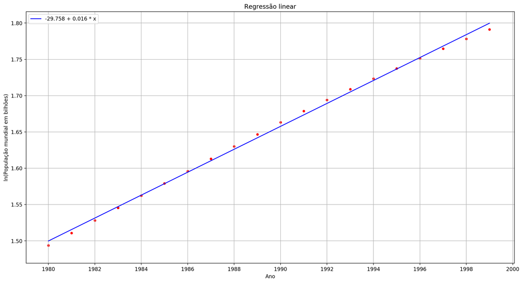

```python
for year, population in data:
    plt.scatter(year, math.log(population), c='red', s=15)

fig = plt.gcf()
fig.set_dpi(200)
fig.set_size_inches(17,9)


plt.title('Regressão linear')
plt.xlabel('Ano')
plt.ticklabel_format(style='plain', axis='x', useOffset=False)
plt.gca().xaxis.set_major_locator(mticker.MultipleLocator(2))
plt.ylabel('ln(População mundial em bilhões)')
plt.grid()

plt.plot(x, y, '-r', label=expr, c='blue')
plt.legend(loc='upper left')
plt.show()
```

```python
predict = int(input('Ano previsto: '))
print(f'{math.exp(predict * b + a)} bilhões de habitantes')
```

```
Ano previsto: 2030
9.86705836480796 bilhões de habitantes
```

# Referências bibliográficas

**Método dos mínimos quadrados: Caso discreto**  
Disponivel em: http://conteudo.icmc.usp.br/pessoas/andretta/ensino/aulas/sme0500-1-13/aula8-quadmindisc.pdf. Acesso em: 27 nov. 2019.  
**Revisão sobre regressão linear**  
Disponivel em: https://pt.khanacademy.org/math/statistics-probability/describing-relationships-quantitative-data/introduction-to-trend-lines/a/linear-regression-review. Acesso em: 27 nov. 2019.